# Introducción a la Econometría Espacial Aplicada - Ejercicios GIS

Irene Farah

Verano 2023

[Descargar - [RMarkdown](https://github.com/ifarah/t/blob/main/Rmd/ejercicios/ejercicio_GIS.Rmd)]

**Agregar puntos a polígonos**

- Leer datos espaciales.
- Leer datos no espaciales (`data.table`), explorar y filtrar datos (`dplyr`).
- Convertir datos no espaciales a espaciales (`sf`).
- Verificar y transformar proyecciones.
- Agregar puntos a polígonos usando `st_intersects` (`sf`).
- Crear mapa para verificar resultado.
- Exportar shapefile con `st_write` (`sf`).

### Agregación de puntos por polígonos

Es común que tengamos datos a nivel punto y los queramos agregar a una escala mayor. Generalmente, tenemos datos socioeconómicos a nivel municipal. Por lo tanto, queremos agregar la información a nivel punto a los polígonos. De esta forma, podemos generar variables para incoporar en nuestras regresiones espaciales.

Agregar el número de tiendas que existen dentro de un polígono. En este caso, cuántas tiendas de frutas y verduras existen por municipio en la Zona Metropolitana del Valle de México (incluye Ciudad de México, 59 municipios del estado de México y 1 municipio del estado de Hidalgo).

Vamos a utilizar `sf` para leer los datos espaciales, hacer transformaciones de proyecciones y hacer intersección entre las tiendas (puntos) y los municipios (polígonos). Primero, para analizar los datos de las tiendas, utilizaremos `dplyr`, mostrando algunos comandos para explorar y filtrar los datos y después con `sf` pasar de una tabla csv (no espacial, pero conteniendo las coordenadas de los puntos) a una tabla sf (espacial).

**Leer los paquetes estadísticos:**

```r
library(data.table)
library(dplyr)
library(sf)
library(ggplot2)
library(tmap)
```

**Importar datos:**

```r
#Importar datos espaciales
muni = st_read("./data/mx_city_metro.shp")
```

Bajar datos de comercio al por menor del DENUE (Directorio Estadístico Nacional de Unidades Económicas) de la [página del INEGI](https://www.inegi.org.mx/app/descarga/default.html) (Instituto Nacional de Estadística y Geografía) de México.

**Leer datos de comercio al por menor y filtrar por geografías de interés:**

```r
#fread lee csv mucho más rápido (data.table)
df=fread("data/denue_inegi_46112-46311_.csv")%>%
  filter(cve_ent==9 | cve_ent==15 | cve_ent==13)# filtrar por entidad federativa (cdmx, hidalgo, edomex)

head(df)
```

```
##         id                         clee
## 1: 8117497 09005461140003241000000000U3
## 2:  774758 09005461121003521000000000U8
## 3:  673456 09005461121008721000000000U9
## 4:  743038 09002461150001821000000000U0
## 5:  673369 09005461121009281000000000U3
## 6:  775603 09016461130005491000000000U0
##                                   nom_estab raz_social codigo_act
## 1:                  02 PRODUCTOS NATURISTAS                461140
## 2: 03 CARNICERIA DE CARNES ROJAS SIN NOMBRE                461121
## 3:                  07 TOCINERIA SIN NOMBRE                461121
## 4:                  10 ABARROTES Y CREMERIA                461150
## 5:                        10 TOCINERIA PEPE                461121
## 6:                              101 VERDURA                461130
##                                                                          nombre_act
```

[output cut: 69 more lines]

Primero tenemos que examinar el tipo de tiendas en nuestros datos para filtrar por comercio al por menor de frutas y verduras.  
**Examinar los tipo de tiendas en los datos (codigos SCIAN):**

```r
df%>%
  group_by(codigo_act)%>%
  summarise(n=n()) #Ver que tipo de tiendas hay dentro del comercio al por menor
```

```
## # A tibble: 19 × 2
##    codigo_act     n
##         <int> <int>
##  1     461121 17898
##  2     461122 22739
##  3     461123  1173
##  4     461130 30134
##  5     461140  6983
##  6     461150 10082
##  7     461160 21450
##  8     461170  5507
##  9     461190 12738
## 10     461211  1711
## 11     461212  2963
## 12     461213  4090
## 13     461220   124
## 14     462111  1288
## 15     462112  7769
## 16     462210   636
## 17     463111  1796
## 18     463112  1446
## 19     463113  5316
```

**Según el código [SCIAN](https://www.inegi.org.mx/contenidos/app/scian/tablaxiv.pdf):**

461121: Comercio al por menor de carnes rojas  
461122: Comercio al por menor de carne de aves  
461123: Comercio al por menor de pescados y mariscos  
461130 Comercio al por menor de frutas y verduras frescas  
461140: Comercio al por menor de semillas y granos alimenticios, especias y chiles secos  
461150: Comercio al por menor de leche, otros productos lácteos y embutidos  
461160: Comercio al por menor de dulces y materias primas para repostería  
461170: Comercio al por menor de paletas de hielo y helados  
461190: Comercio al por menor de otros alimentos  
461211: Comercio al por menor de vinos y licores  
461212: Comercio al por menor de cerveza  
461213: Comercio al por menor de bebidas no alcohólicas y hielo  
461220: Comercio al por menor de cigarros, puros y tabaco  
462111: Comercio al por menor en supermercados  
462112: Comercio al por menor en minisupers  
462210: Comercio al por menor en tiendas departamentales  
463111: Comercio al por menor de telas  
463112: Comercio al por menor de blancos  
463113: Comercio al por menor de artículos de mercería y bonetería

**Filtrar los datos por comercio al por menor de frutas y verduras:**

```r
fv= df%>%
  filter(codigo_act==461130)

head(fv)
```

```
##         id                         clee                            nom_estab
## 1:  775603 09016461130005491000000000U0                          101 VERDURA
## 2: 7802536 09002461130008201000000000U0                       104 VERDULERIA
## 3:  742963 09002461130000071000000000U5             108 VER5DURAS EL BURRITO
## 4:  743108 09002461130003341000000000U9                119 VERDURAS Y FLORES
## 5:  743034 09002461130003911000000000U9 122-113 FRUTAS Y VERDURAS SIN NOMBRE
## 6:  743106 09002461130004291000000000U5                         123 VERDURAS
##    raz_social codigo_act                                         nombre_act
## 1:                461130 Comercio al por menor de frutas y verduras frescas
## 2:                461130 Comercio al por menor de frutas y verduras frescas
## 3:                461130 Comercio al por menor de frutas y verduras frescas
## 4:                461130 Comercio al por menor de frutas y verduras frescas
## 5:                461130 Comercio al por menor de frutas y verduras frescas
## 6:                461130 Comercio al por menor de frutas y verduras frescas
##           per_ocu tipo_vial           nom_vial tipo_v_e_1      nom_v_e_1
```

[output cut: 62 more lines]

**Pasar de csv a sf:**

```r
fv_sf = st_as_sf(df,               # nombre tabla
                     coords = c('longitud', 'latitud'),    # columnas con long y lat
                     crs = 4326, remove = FALSE)              #  CRS, con codigo EPSG

head(fv_sf)
```

```
## Simple feature collection with 6 features and 42 fields
## Geometry type: POINT
## Dimension:     XY
## Bounding box:  xmin: -99.18782 ymin: 19.39871 xmax: -99.14869 ymax: 19.50113
## CRS:           EPSG:4326
##        id                         clee                                nom_estab
## 1 8117497 09005461140003241000000000U3                  02 PRODUCTOS NATURISTAS
## 2  774758 09005461121003521000000000U8 03 CARNICERIA DE CARNES ROJAS SIN NOMBRE
## 3  673456 09005461121008721000000000U9                  07 TOCINERIA SIN NOMBRE
## 4  743038 09002461150001821000000000U0                  10 ABARROTES Y CREMERIA
## 5  673369 09005461121009281000000000U3                        10 TOCINERIA PEPE
## 6  775603 09016461130005491000000000U0                              101 VERDURA
##   raz_social codigo_act
## 1                461140
## 2                461121
```

[output cut: 74 more lines]

Para verificar que tanto puntos como polígonos están en la misma proyección, verificar sus SRC (Sistema de Referencia de Coordenadas) con `st_crs.` Si están en SRC distintas, usar `st_transform`.

**Verificar SRC:**

```r
st_crs(muni)
```

```
## Coordinate Reference System:
##   No user input
##   wkt:
## PROJCS["Lambert_Conformal_Conic",
##     GEOGCS["GCS_GRS 1980(IUGG, 1980)",
##         DATUM["unknown",
##             SPHEROID["GRS80",6378137,298.257222101]],
##         PRIMEM["Greenwich",0],
##         UNIT["Degree",0.017453292519943295]],
##     PROJECTION["Lambert_Conformal_Conic_2SP"],
##     PARAMETER["standard_parallel_1",17.5],
##     PARAMETER["standard_parallel_2",29.5],
##     PARAMETER["latitude_of_origin",12],
##     PARAMETER["central_meridian",-102],
##     PARAMETER["false_easting",2500000],
##     PARAMETER["false_northing",0],
##     UNIT["Meter",1]]
```

```r
st_crs(fv_sf)
```

```
## Coordinate Reference System:
##   User input: EPSG:4326
##   wkt:
## GEOGCS["WGS 84",
##     DATUM["WGS_1984",
##         SPHEROID["WGS 84",6378137,298.257223563,
##             AUTHORITY["EPSG","7030"]],
##         AUTHORITY["EPSG","6326"]],
##     PRIMEM["Greenwich",0,
##         AUTHORITY["EPSG","8901"]],
##     UNIT["degree",0.0174532925199433,
##         AUTHORITY["EPSG","9122"]],
##     AUTHORITY["EPSG","4326"]]
```

**Transformar SRC:**

```r
municipios_4326 = st_transform(muni, 4326)
st_crs(municipios_4326)
```

```
## Coordinate Reference System:
##   User input: EPSG:4326
##   wkt:
## GEOGCS["WGS 84",
##     DATUM["WGS_1984",
##         SPHEROID["WGS 84",6378137,298.257223563,
##             AUTHORITY["EPSG","7030"]],
##         AUTHORITY["EPSG","6326"]],
##     PRIMEM["Greenwich",0,
##         AUTHORITY["EPSG","8901"]],
##     UNIT["degree",0.0174532925199433,
##         AUTHORITY["EPSG","9122"]],
##     AUTHORITY["EPSG","4326"]]
```

Para estar seguros de nuestros datos, mapeamos los municipios y las tiendas. Noten que muchas tiendas están fuera de nuestro polígono de interés porque incluímos municipios de los estados que no se encuentran dentro de la Zona Metropolitana del Valle de México.

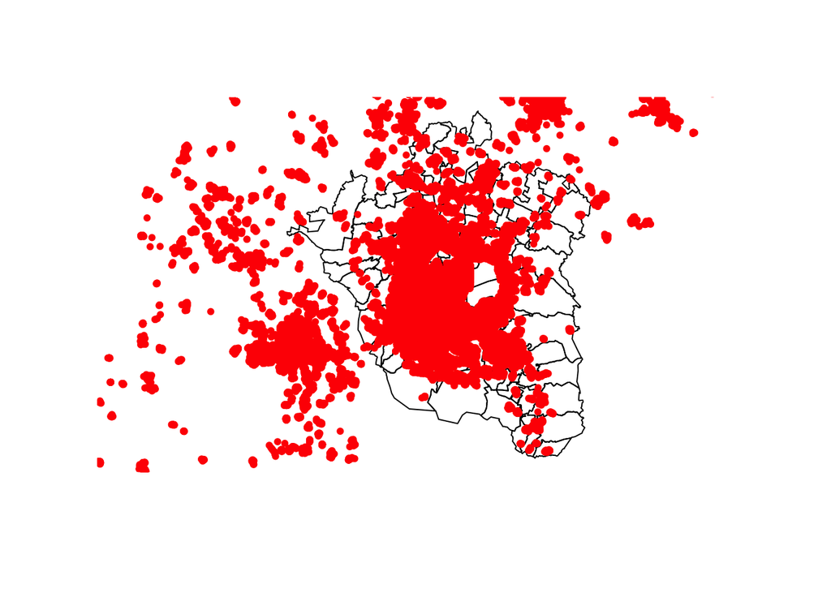

```r
plot(municipios_4326$geometry)
plot(fv_sf$geometry, pch=20, col="red", size=.5, add=T)
```

**Agregar puntos a polígonos:**

```r
#Numero de abarrotes por municipio
municipios_4326$sum_fv <- lengths(st_intersects(municipios_4326, fv_sf))
```

**Mapear los datos agregados a nivel municipal:**

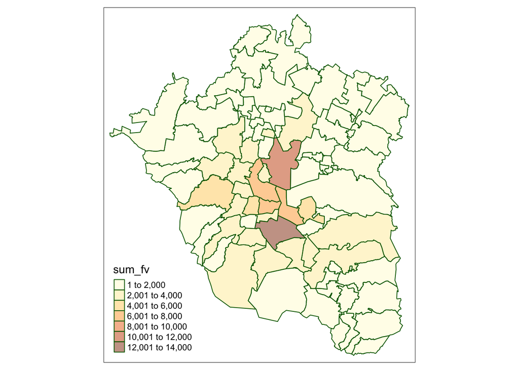

```r
tm_shape(municipios_4326) +
  tm_polygons(col = 'sum_fv',
              border.col = 'darkgreen',
              alpha = 0.5)
```

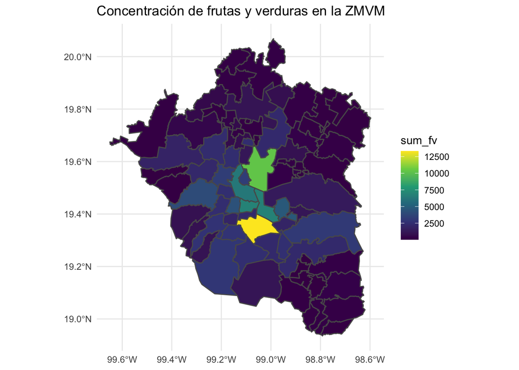

```r
ggplot(municipios_4326, aes(fill = sum_fv)) +
  geom_sf() +
  scale_fill_viridis_c() +
  theme_minimal() +
  labs(title = "Concentración de frutas y verduras en la ZMVM")
```

```r
st_write(municipios_4326, "municipios_fv.shp")
```

```
## Writing layer `municipios_fv' to data source
##   `municipios_fv.shp' using driver `ESRI Shapefile'
## Writing 76 features with 41 fields and geometry type Multi Polygon.
```